# Effects of Dexamethasone on NCD/HFD Mouse Quadriceps

Laura Gunder and Dave Bridges

January 8, 2018

# Purpose

to examine the molecular effects of dexamethasone at varying lengths of treatment on obese and non-obese mice

# Experimental Details

The relevant protocols used were:

- RNA Purification, a modified version of http://bridgeslab.sph.umich.edu/protocols/index.php?title=Preparation_of_RNA_Samples_from_Mouse_Tissues&oldid=1359
- cDNA Synthesis, used 2 ug then diluted cDNA 5X prior to qPCR: http://bridgeslab.sph.umich.edu/protocols/index.php?title=First_Strand_cDNA_Synthesis_(AB_Kit)&oldid=1242
- qPCR: http://bridgeslab.sph.umich.edu/protocols/index.php?title=QPCR&oldid=1252

There is two cohorts of mice from this, run separately on different qPCR runs.

# Raw Data

The sample mapping is found in ../../data/raw/Time Course Sample Key.csv and the qPCR data can be found in ../../data/raw/Time Course Quadriceps qPCR - Combined Well Results.csv`. This analysis can be found in /Users/davebrid/Documents/GitHub/CushingAcromegalyStudy/scripts/scripts-muscle and was most recently run on Tue Jan 21 15:15:09 2020.

Samples where Ct range between technical replicates exceeds 1

| Experiment Name | Sample Name | Target Name | Time | Diet | Ct.mean | Ct.min | Ct.max | Ct.range |
| --- | --- | --- | --- | --- | --- | --- | --- | --- |
| 2018-07-16 lg.eds | 2630 | GDF15 | 14 | NCD | 33.9 | 32.4 | 36.7 | 4.29 |
| 2018-07-16 lg.eds | 2645 | GDF15 | 3 | HFD | 34.9 | 33.1 | 37.3 | 4.13 |
| 2018-07-16 lg.eds | 2618 | GDF15 | 3 | NCD | 33.5 | 32.0 | 35.8 | 3.74 |
| 2018-07-16 lg.eds | 2639 | GDF15 | 7 | NCD | 34.4 | 33.3 | 36.5 | 3.18 |
| 2018-07-16 lg.eds | 2643 | GDF15 | 7 | HFD | 34.7 | 33.5 | 36.6 | 3.15 |
| 2018-07-16 lg.eds | 2616 | GDF15 | 3 | NCD | 32.2 | 31.3 | 34.4 | 3.11 |
| 2018-07-09 LG.eds | 2645 | GDF15 | 3 | HFD | 35.1 | 33.5 | 36.5 | 2.95 |
| 2018-07-16 lg.eds | 2631 | GDF15 | 14 | NCD | 33.8 | 32.6 | 35.5 | 2.91 |
| 2018-07-16 lg.eds | 2624 | GDF15 | 0 | HFD | 33.4 | 32.5 | 35.2 | 2.67 |
| 2018-07-16 lg.eds | 2627 | GDF15 | 0 | HFD | 35.1 | 34.3 | 36.9 | 2.67 |
| 2018-07-09 LG.eds | 2626 | GDF15 | 0 | HFD | 33.0 | 31.7 | 34.4 | 2.64 |
| 2018-07-16 lg.eds | 2633 | GDF15 | 14 | HFD | 35.1 | 33.7 | 36.3 | 2.61 |
| 2018-07-09 LG.eds | 2644 | GDF15 | 3 | HFD | 33.6 | 32.3 | 34.9 | 2.61 |
| 2018-07-09 LG.eds | 2618 | GDF15 | 3 | NCD | 33.5 | 32.6 | 35.2 | 2.60 |
| 2018-07-09 LG.eds | 2639 | GDF15 | 7 | NCD | 34.3 | 33.0 | 35.5 | 2.55 |
| 2018-07-16 lg.eds | 2626 | GDF15 | 0 | HFD | 34.6 | 33.3 | 35.8 | 2.52 |
| 2018-07-16 lg.eds | 2621 | GDF15 | 0 | NCD | 34.7 | 33.7 | 36.1 | 2.39 |
| 2018-07-16 lg.eds | 2641 | GDF15 | 7 | HFD | 33.6 | 32.3 | 34.7 | 2.33 |
| 2018-07-09 LG.eds | 2629 | GDF15 | 14 | NCD | 33.7 | 32.5 | 34.8 | 2.32 |
| 2018-07-16 lg.eds | 2632 | GDF15 | 14 | HFD | 34.1 | 33.4 | 35.4 | 2.08 |
| 2018-07-16 lg.eds | 2647 | GDF15 | 3 | HFD | 33.8 | 32.5 | 34.5 | 2.05 |
| 2018-07-09 LG.eds | 2619 | GDF15 | 3 | NCD | 30.7 | 29.6 | 31.7 | 2.03 |
| 2018-07-09 LG.eds | 2633 | GDF15 | 14 | HFD | 33.3 | 32.4 | 34.3 | 1.91 |
| 2018-07-09 LG.eds | 2625 | Foxo3 | 0 | HFD | 23.5 | 22.8 | 24.7 | 1.87 |
| 2018-07-16 lg.eds | 2622 | GDF15 | 0 | NCD | 32.9 | 32.0 | 33.9 | 1.84 |
| 2018-07-16 lg.eds | 2617 | GDF15 | 3 | NCD | 30.6 | 30.0 | 31.6 | 1.60 |
| 2018-07-09 LG.eds | 2638 | GDF15 | 7 | NCD | 29.9 | 29.2 | 30.7 | 1.47 |
| 2018-07-16 lg.eds | 2644 | GDF15 | 3 | HFD | 33.1 | 32.3 | 33.7 | 1.38 |
| 2018-07-09 LG.eds | 2627 | GDF15 | 0 | HFD | 36.0 | 35.3 | 36.7 | 1.37 |
| 2018-07-16 lg.eds | 2629 | GDF15 | 14 | NCD | 32.0 | 31.5 | 32.9 | 1.36 |
| 2018-07-09 LG.eds | 2632 | GDF15 | 14 | HFD | 34.4 | 33.7 | 35.1 | 1.34 |
| 2018-07-09 LG.eds | 2625 | GDF15 | 0 | HFD | 34.1 | 33.7 | 35.0 | 1.30 |
| 2018-07-16 lg.eds | 2620 | GDF15 | 0 | NCD | 34.1 | 33.6 | 34.9 | 1.30 |
| 2018-07-16 lg.eds | 2640 | GDF15 | 7 | HFD | 32.2 | 31.4 | 32.7 | 1.29 |
| 2018-07-09 LG.eds | 2620 | GDF15 | 0 | NCD | 34.2 | 33.6 | 34.9 | 1.28 |
| 2018-07-16 lg.eds | 2625 | GDF15 | 0 | HFD | 33.5 | 32.8 | 34.1 | 1.25 |
| 2018-07-16 lg.eds | 2646 | GDF15 | 3 | HFD | 33.3 | 32.6 | 33.9 | 1.22 |
| 2018-07-16 lg.eds | 2637 | GDF15 | 7 | NCD | 30.0 | 29.3 | 30.3 | 1.03 |

Number of samples for qPCR analysis

| Diet | Time | n |
| --- | --- | --- |
| NCD | 0 | 7 |
| NCD | 3 | 7 |
| NCD | 7 | 7 |
| NCD | 14 | 7 |
| HFD | 0 | 7 |
| HFD | 3 | 7 |
| HFD | 7 | 7 |
| HFD | 14 | 7 |

We removed several wells due to technical outliers:

- J1,J6,J7,J9,J11,J12,G7,D13,D16,A15,C24,C17,J10,B21 in the first experiment.
- P6,G5,G7,G4,G1,G2,G8,G3,J10,O21,A14,B22,A20,C4,A7,B15,E7,A17,C1 in the second experiment.
- G7,P16,M13,P15 in the third experiment.
- B3,G2,F20,C1,C3,C2,C4,F3,H23,G10,E7,F14,G4,F24,G3,E15,D1,G16,F1,G12,D8 in the fourth experiment.
- A9 in the fifth experiment.

We also removed one entire amplification, Foxo1 from the third experiment as none of those samples amplified

# Analysis

All mRNA levels were adjusted to **Pgk1**, then normalized to **NCD** at time **0**.

# Foxo1 versus Foxo3a

Relative amplification of Foxo1 and Foxo3

| Target Name | Ct | DCt | Quant |
| --- | --- | --- | --- |
| Foxo1 | 24.5 | 0.000 | 1.000 |
| Foxo3 | 24.7 | 0.262 | 0.834 |

# Plots of changes in gene expression

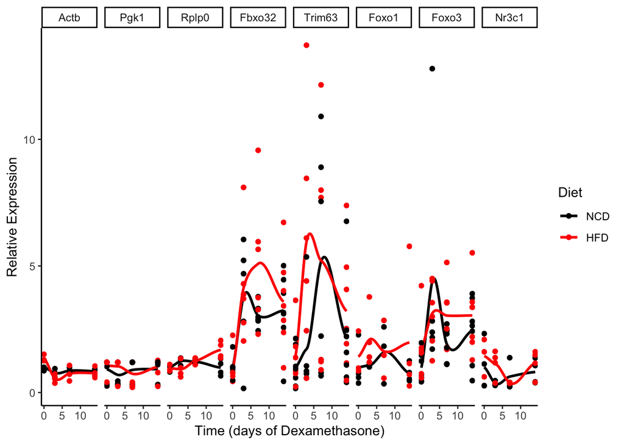

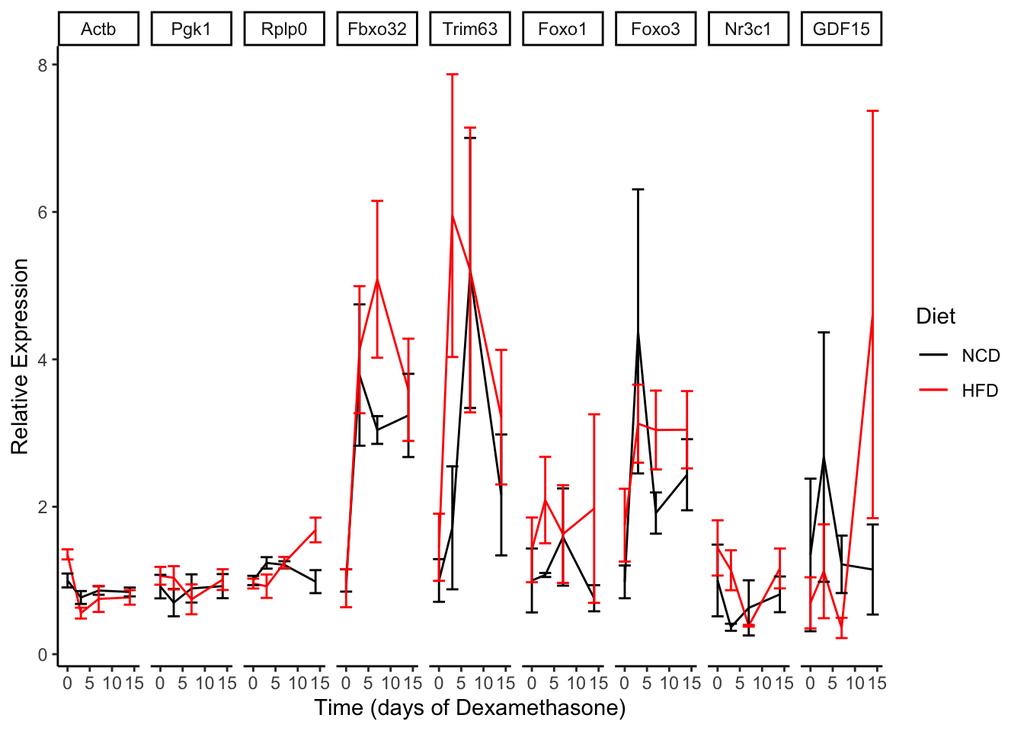

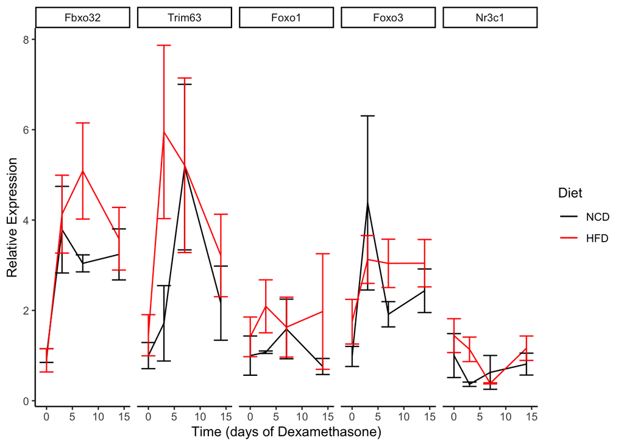

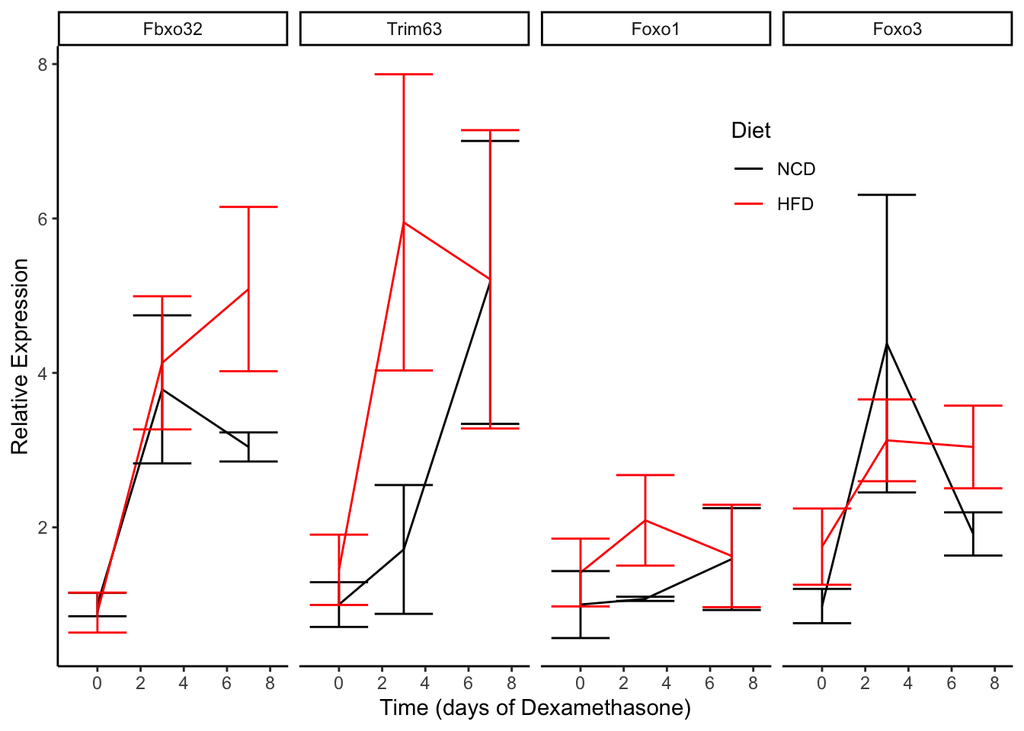

## Statistics

### Baseline Effects of Diet

First tested if there was an effect at baseline for expression of *Trim63* and *Fbxo32*.

Pairwise statistics for baseline effects of diet.

| Target Name | HFD.Effect | Shapiro.p | Levene.p | Wilcox.p | Welch.p | Student.p |
| --- | --- | --- | --- | --- | --- | --- |
| Fbxo32 | 0.896 | 0.005 | 0.574 | 0.138 | 0.752 | 0.739 |
| Trim63 | 1.450 | 0.306 | 0.515 | 0.731 | 0.452 | 0.431 |
| Foxo1 | 1.415 | 0.088 | 0.989 | 0.229 | 0.565 | 0.560 |
| Foxo3 | 1.784 | 0.075 | 0.440 | 0.181 | 0.226 | 0.187 |
| Nr3c1 | 1.441 | 0.238 | 0.602 | 0.629 | 0.528 | 0.545 |
| GDF15 | 0.518 | 0.011 | 0.538 | 0.886 | 0.587 | 0.574 |

### Effects of Dexamethasone Over Time

First did pairwise tests at each time point.

Pairwise statistics for effects of diet in dexamethasone treated animals.

| Time | Target Name | HFD.Effect | Shapiro.p.HFD | Shaprio.p.NCD | Shapiro.p | Levene.p | Wilcox.p | Welch.p | Student.p |
| --- | --- | --- | --- | --- | --- | --- | --- | --- | --- |
| 0 | Fbxo32 | 0.896 | 0.005 | 0.098 | 0.005 | 0.574 | 0.138 | 0.752 | 0.739 |
| 0 | Trim63 | 1.450 | 0.306 | 0.385 | 0.306 | 0.515 | 0.731 | 0.452 | 0.431 |
| 0 | Foxo1 | 1.415 | 0.119 | 0.088 | 0.088 | 0.989 | 0.229 | 0.565 | 0.560 |
| 0 | Foxo3 | 1.784 | 0.075 | 0.247 | 0.075 | 0.440 | 0.181 | 0.226 | 0.187 |
| 0 | Nr3c1 | 1.441 | 0.630 | 0.238 | 0.238 | 0.602 | 0.629 | 0.528 | 0.545 |
| 3 | Fbxo32 | 1.091 | 0.149 | 0.494 | 0.149 | 0.730 | 0.792 | 0.806 | 0.804 |
| 3 | Trim63 | 3.471 | 0.824 | 0.002 | 0.002 | 0.138 | 0.177 | 0.086 | 0.096 |
| 3 | Foxo1 | 1.946 | 0.213 | 0.370 | 0.213 | 0.203 | 0.057 | 0.181 | 0.203 |
| 3 | Foxo3 | 0.714 | 0.596 | 0.002 | 0.002 | 0.494 | 0.792 | 0.593 | 0.546 |
| 3 | Nr3c1 | 3.116 | 0.466 | 0.678 | 0.466 | 0.241 | 0.114 | 0.062 | 0.063 |
| 7 | Fbxo32 | 1.672 | 0.506 | 0.824 | 0.506 | 0.026 | 0.180 | 0.114 | 0.088 |
| 7 | Trim63 | 1.008 | 0.133 | 0.209 | 0.133 | 0.890 | 0.818 | 0.988 | 0.988 |
| 7 | Foxo1 | 1.025 | 0.772 | 0.650 | 0.650 | 0.986 | 1.000 | 0.968 | 0.968 |
| 7 | Foxo3 | 1.588 | 0.464 | 0.302 | 0.302 | 0.139 | 0.132 | 0.101 | 0.092 |
| 7 | Nr3c1 | 0.614 | 0.434 | 0.078 | 0.078 | 0.359 | 0.700 | 0.584 | 0.553 |
| 14 | Fbxo32 | 1.107 | 0.982 | 0.572 | 0.572 | 0.627 | 0.902 | 0.705 | 0.705 |
| 14 | Trim63 | 1.488 | 0.701 | 0.024 | 0.024 | 0.582 | 0.318 | 0.407 | 0.407 |
| 14 | Foxo1 | 2.604 | 0.046 | 0.391 | 0.046 | 0.319 | 0.886 | 0.413 | 0.383 |
| 14 | Foxo3 | 1.251 | 0.592 | 0.499 | 0.499 | 0.883 | 0.710 | 0.408 | 0.408 |
| 14 | Nr3c1 | 1.433 | 0.376 | 0.273 | 0.273 | 0.910 | 0.343 | 0.371 | 0.370 |

Also analysed this with a linear model with diet and time as covariates, allowing for an interaction. Since time and effect were nonlinear with respect to each other, used time as a factor, allowing for each time point to be treated independently.

Linear model for effects of time and diet on Fbxo32

| term | df | sumsq | meansq | statistic | p.value |
| --- | --- | --- | --- | --- | --- |
| Diet | 1 | 7.16 | 7.16 | 2.587 | 0.115 |
| as.factor(Time) | 3 | 78.71 | 26.24 | 9.478 | 0.000 |
| Diet:as.factor(Time) | 3 | 8.25 | 2.75 | 0.993 | 0.405 |
| Residuals | 42 | 116.26 | 2.77 | NA | NA |

Linear model for effects of time and diet on Trim63

| term | df | sumsq | meansq | statistic | p.value |
| --- | --- | --- | --- | --- | --- |
| Diet | 1 | 26.6 | 26.58 | 2.70 | 0.108 |
| as.factor(Time) | 3 | 106.5 | 35.50 | 3.60 | 0.021 |
| Diet:as.factor(Time) | 3 | 30.8 | 10.26 | 1.04 | 0.384 |
| Residuals | 42 | 413.7 | 9.85 | NA | NA |

Linear model for effects of time and diet on Nr3c1

| term | df | sumsq | meansq | statistic | p.value |
| --- | --- | --- | --- | --- | --- |
| Diet | 1 | 0.711 | 0.711 | 1.951 | 0.178 |
| as.factor(Time) | 3 | 1.766 | 0.589 | 1.616 | 0.217 |
| Diet:as.factor(Time) | 3 | 0.848 | 0.283 | 0.775 | 0.521 |
| Residuals | 20 | 7.286 | 0.364 | NA | NA |

Linear model for effects of time and diet on Foxo1

| term | df | sumsq | meansq | statistic | p.value |
| --- | --- | --- | --- | --- | --- |
| Diet | 1 | 3.842 | 3.842 | 2.315 | 0.144 |
| as.factor(Time) | 3 | 0.709 | 0.236 | 0.142 | 0.933 |
| Diet:as.factor(Time) | 3 | 1.496 | 0.499 | 0.300 | 0.825 |
| Residuals | 20 | 33.199 | 1.660 | NA | NA |

Linear model for effects of time and diet on Foxo3

| term | df | sumsq | meansq | statistic | p.value |
| --- | --- | --- | --- | --- | --- |
| Diet | 1 | 2.66 | 2.66 | 0.796 | 0.377 |
| as.factor(Time) | 3 | 33.17 | 11.05 | 3.307 | 0.029 |
| Diet:as.factor(Time) | 3 | 9.61 | 3.20 | 0.959 | 0.421 |
| Residuals | 42 | 140.39 | 3.34 | NA | NA |

# Interpretation

None of these time courses have a significant interaction between time and diet